# Análisis completo del ensayo clínico

Import → Tidy → Visualize → Model → Report — el flujo de datos de R4DS aplicado al Día 4

Author

Affiliation

Efraín García Sánchez & Filip Andras

CIMCYC — Universidad de Granada

Published

17 April 2026

# El flujo de datos de R4DS

El libro [*R for Data Science*](https://r4ds.hadley.nz/) (Wickham & Grolemund) describe un ciclo que **se repite en cualquier análisis de datos**:

**TipEl ciclo no es lineal**

En la práctica, vuelves de **Visualize** a **Tidy** (un gráfico revela un dato raro → toca limpiar más), de **Model** a **Visualize** (necesitas un gráfico de residuos para diagnosticar el modelo), de **Report** a **Tidy** (te das cuenta de que necesitas el dataset en otro formato para una tabla).

Ese es el día a día del análisis de datos. Cada flecha hacia atrás es **aprender algo nuevo de los datos** — no un error.

Este documento aplica este flujo al ensayo clínico del curso:

| Paso | Qué se hace | Funciones clave |
| --- | --- | --- |
| **Import** | Cargar el dataset preprocesado | `read_csv()` |
| **Tidy** | Pivotar a formato largo (paciente × timepoint) | `pivot_longer()` con `.value` |
| **Transform** | Recodificar `timepoint` como factor ordenado | `mutate()`, `factor()` |
| **Visualize** | Boxplots, gráfico de interacción | `boxplot()`, `ggplot()`, `emmip()` |
| **Model** | ANOVA mixto (timepoint × group) | `aov_ez()`, `emmeans()`, `eta_squared()` |
| **Report** | Interpretación clínica de los resultados | texto + APA |

# Paso 1 · Import

## Cargar paquetes

```r
library(tidyverse)    # readr, dplyr, tidyr, ggplot2
library(afex)         # aov_ez() para ANOVA mixto
library(emmeans)      # comparaciones post-hoc
library(effectsize)   # eta_squared, cohens_d
library(easystats)    # report() y check_model()
library(knitr)        # kable() para tablas limpias en HTML
library(jtools)       # theme_apa() para graficos estilo APA

options(scipen = 999, width = 120)
```

## Cargar los datos preprocesados

```r
data_processed <- read_csv("../exercises/data/processed_data/preprocessed_data.csv")

# inspeccion rapida
glimpse(data_processed)
```

```
Rows: 300
Columns: 29
$ patient_id           <dbl> 1, 2, 3, 4, 5, 6, 7, 8, 9, 10, 11, 12, 13, 14, 15, 16, 17, 18, 19, 20, 21, 22, 23, 24, 25…
$ site_id              <chr> "site_01", "site_01", "site_02", "site_01", "site_02", "site_03", "site_01", "site_01", "…
$ group                <chr> "CBT", "CBT", "CBT", "CBT", "CBT", "CBT", "CBT", "CBT", "CBT", "CBT", "CBT", "CBT", "CBT"…
$ sex                  <chr> "male", "male", "female", "male", "male", "female", "male", "female", "male", "male", "fe…
$ age                  <dbl> 42, 23, 56, 39, 36, 27, 42, 32, 36, 57, 40, 29, 44, 38, 49, 59, 30, 47, 43, 53, 39, 52, 2…
$ n_sessions           <dbl> 11, 13, 15, 15, 10, 17, 7, 15, 10, 6, 6, 13, 19, 13, 15, 15, 10, 15, 13, 13, 15, 14, 10, …
$ anxiety_pre          <dbl> 20.0, 17.7, 15.5, 15.9, 12.7, 14.3, 14.3, 10.0, 15.0, 16.0, 14.7, 17.6, 16.9, 14.0, 17.2,…
$ anxiety_post         <dbl> 16.6, 12.3, 11.0, 11.4, 9.1, 8.4, 11.2, 5.9, 11.6, 15.0, 8.2, 12.9, 11.7, 8.0, 11.4, 8.2,…
$ anxiety_followup     <dbl> 16.6, 12.8, 14.1, 12.3, 10.1, 11.8, 12.7, 4.8, 11.4, 15.1, 10.8, 14.2, 13.1, 9.0, 11.4, 1…
$ depression_pre       <dbl> 13.0, 14.4, 15.2, 15.4, 12.5, 13.4, 14.0, 12.1, 16.6, 10.8, 18.3, 20.5, 16.7, 10.0, 16.6,…
$ depression_post      <dbl> 6.0, 8.8, 7.0, 15.8, 1.3, 12.6, 11.2, 4.8, 12.3, 7.2, 19.8, 20.3, 12.6, 4.0, 11.8, 6.3, 7…
$ depression_followup  <dbl> 4.5, 7.7, 8.1, 19.6, 4.0, 11.9, 13.4, 5.2, 13.4, 8.2, 25.5, 18.4, 13.3, 0.9, 13.5, 9.0, 1…
$ wellbeing_pre        <dbl> 46.7, 60.8, 68.7, 52.4, 66.4, 71.9, 66.0, 58.8, 54.1, 68.2, 45.2, 35.0, 51.7, 62.1, 45.2,…
```

[output cut: 16 more lines]

**Tip¿Por qué partimos de `data_processed` y no de los datos crudos?**

`preprocessed_data.csv` es el resultado del pipeline de Día 3 Bloque 1: ya tiene los datos del ensayo unidos con los del seguimiento, las columnas renombradas (rosenberg → self_esteem, ucla → loneliness), y las variables derivadas (`mejora`, `cambio`, `gravedad_post`).

Partir de aquí significa que cada día empieza con los datos en el estado que necesita el análisis del día — sin repetir los pasos previos.

# Paso 2 · Tidy

## ¿Por qué necesitamos formato largo?

Nuestros datos están en formato **ancho**: cada paciente tiene una fila, y cada combinación de constructo × timepoint es una columna (`anxiety_pre`, `anxiety_post`, `anxiety_followup`, etc.).

Para el ANOVA mixto necesitamos formato **largo**: una fila por *medición* (paciente × timepoint), con cada constructo en su propia columna.

## Pivotar con `.value` (todos los constructos a la vez)

```r
data_long <- data_processed |>
  pivot_longer(
    # cols: las columnas que vamos a apilar (5 constructos x 3 timepoints = 15)
    cols          = c(starts_with("anxiety"),
                      starts_with("depression"),
                      starts_with("wellbeing"),
                      starts_with("loneliness"),
                      starts_with("self_esteem")),

    # names_pattern: cada nombre se parte en (constructo)_(timepoint)
    names_pattern = "(.*)_(pre|post|followup)",

    # names_to: el primer trozo se vuelve nombre de columna (.value),
    # el segundo trozo va a una columna llamada "timepoint"
    names_to      = c(".value", "timepoint")
  ) |>
  # ordenar timepoint cronologicamente como factor
  mutate(timepoint = factor(timepoint, levels = c("pre", "post", "followup")))

# verificar
glimpse(data_long)
```

```
Rows: 900
Columns: 20
$ patient_id      <dbl> 1, 1, 1, 2, 2, 2, 3, 3, 3, 4, 4, 4, 5, 5, 5, 6, 6, 6, 7, 7, 7, 8, 8, 8, 9, 9, 9, 10, 10, 10, 1…
$ site_id         <chr> "site_01", "site_01", "site_01", "site_01", "site_01", "site_01", "site_02", "site_02", "site_…
$ group           <chr> "CBT", "CBT", "CBT", "CBT", "CBT", "CBT", "CBT", "CBT", "CBT", "CBT", "CBT", "CBT", "CBT", "CB…
$ sex             <chr> "male", "male", "male", "male", "male", "male", "female", "female", "female", "male", "male", …
$ age             <dbl> 42, 42, 42, 23, 23, 23, 56, 56, 56, 39, 39, 39, 36, 36, 36, 27, 27, 27, 42, 42, 42, 32, 32, 32…
$ n_sessions      <dbl> 11, 11, 11, 13, 13, 13, 15, 15, 15, 15, 15, 15, 10, 10, 10, 17, 17, 17, 7, 7, 7, 15, 15, 15, 1…
$ city            <chr> "Granada", "Granada", "Granada", "Granada", "Granada", "Granada", "Sevilla", "Sevilla", "Sevil…
$ region          <chr> "Andalucia", "Andalucia", "Andalucia", "Andalucia", "Andalucia", "Andalucia", "Andalucia", "An…
$ director        <chr> "Dr. Garcia", "Dr. Garcia", "Dr. Garcia", "Dr. Garcia", "Dr. Garcia", "Dr. Garcia", "Dra. Lope…
$ capacity        <dbl> 60, 60, 60, 60, 60, 60, 45, 45, 45, 60, 60, 60, 45, 45, 45, 35, 35, 35, 60, 60, 60, 60, 60, 60…
$ mejora          <dbl> 3.4, 3.4, 3.4, 5.4, 5.4, 5.4, 4.5, 4.5, 4.5, 4.5, 4.5, 4.5, 3.6, 3.6, 3.6, 5.9, 5.9, 5.9, 3.1,…
$ mejora_followup <dbl> 3.4, 3.4, 3.4, 4.9, 4.9, 4.9, 1.4, 1.4, 1.4, 3.6, 3.6, 3.6, 2.6, 2.6, 2.6, 2.5, 2.5, 2.5, 1.6,…
$ cambio          <chr> "mejora", "mejora", "mejora", "mejora", "mejora", "mejora", "mejora", "mejora", "mejora", "mej…
$ gravedad_post   <chr> "grave", "grave", "grave", "moderada", "moderada", "moderada", "moderada", "moderada", "modera…
$ timepoint       <fct> pre, post, followup, pre, post, followup, pre, post, followup, pre, post, followup, pre, post,…
$ anxiety         <dbl> 20.0, 16.6, 16.6, 17.7, 12.3, 12.8, 15.5, 11.0, 14.1, 15.9, 11.4, 12.3, 12.7, 9.1, 10.1, 14.3,…
$ depression      <dbl> 13.0, 6.0, 4.5, 14.4, 8.8, 7.7, 15.2, 7.0, 8.1, 15.4, 15.8, 19.6, 12.5, 1.3, 4.0, 13.4, 12.6, …
$ wellbeing       <dbl> 46.7, 61.4, 57.0, 60.8, 54.2, 51.7, 68.7, 81.9, 81.2, 52.4, 66.2, 69.5, 66.4, 80.9, 85.2, 71.9…
$ loneliness      <dbl> 27, 24, 20, 32, 25, 25, 25, 19, 16, 29, 25, 25, 16, 14, 13, 25, 25, 25, 19, 19, 20, 20, 13, 12…
$ self_esteem     <dbl> 25, 27, 26, 23, 24, 26, 29, 31, 31, 22, 26, 25, 33, 33, 34, 22, 19, 21, 39, 40, 40, 36, 40, 34…
```

**Note¿Por qué `.value`?**

Sin `.value`, todos los números se apilan en una sola columna `value` y necesitas filtrar por `variable` cada vez que quieres analizar uno. Con `.value`, cada constructo (anxiety, depression, …) tiene su propia columna y puedes pasar a `aov_ez(dv = "anxiety", ...)` directamente.

Si quieres profundizar, ver el documento `pivot_longer_multiples.html`.

```r
# 300 pacientes x 3 timepoints = 900 filas
nrow(data_long)
```

```
[1] 900
```

```r
# cada paciente tiene exactamente 3 timepoints
data_long |>
  count(patient_id) |>
  count(n)
```

```
# A tibble: 1 × 2
      n    nn
  <int> <int>
1     3   300
```

```r
# cada combinacion grupo x timepoint tiene 100 pacientes
data_long |>
  count(group, timepoint)
```

```
# A tibble: 9 × 3
  group           timepoint     n
  <chr>           <fct>     <int>
1 CBT             pre         100
2 CBT             post        100
3 CBT             followup    100
4 control         pre         100
5 control         post        100
6 control         followup    100
7 pharmacological pre         100
8 pharmacological post        100
9 pharmacological followup    100
```

# Paso 3 · Transform

En este punto los datos ya están listos. Pero antes de modelar, podemos crear **resúmenes intermedios** que serán útiles tanto para visualizar como para reportar.

## Descriptivos por grupo y timepoint

```r
descriptivos <- data_long |>
  summarise(
    media = round(mean(anxiety), 2),
    dt    = round(sd(anxiety), 2),
    n     = n(),
    se    = round(sd(anxiety) / sqrt(n()), 2),
    .by   = c(group, timepoint)
  )

descriptivos |>
  kable(
    format    = "html",
    caption   = "Descriptivos de ansiedad por grupo y timepoint",
    col.names = c("Grupo", "Momento", "Media", "DT", "n", "SE")
  )
```

Descriptivos de ansiedad por grupo y timepoint

| Grupo | Momento | Media | DT | n | SE |
| --- | --- | --- | --- | --- | --- |
| CBT | pre | 15.08 | 2.14 | 100 | 0.21 |
| CBT | post | 10.78 | 2.84 | 100 | 0.28 |
| CBT | followup | 11.72 | 2.97 | 100 | 0.30 |
| pharmacological | pre | 15.65 | 2.19 | 100 | 0.22 |
| pharmacological | post | 12.72 | 2.73 | 100 | 0.27 |
| pharmacological | followup | 15.40 | 3.08 | 100 | 0.31 |
| control | pre | 15.74 | 2.14 | 100 | 0.21 |
| control | post | 15.17 | 2.50 | 100 | 0.25 |
| control | followup | 14.80 | 2.91 | 100 | 0.29 |

**TipEl argumento `.by` es nuevo (dplyr 1.1+)**

Equivale a `group_by(group, timepoint) |> summarise(...) |> ungroup()` pero en una sola línea, sin grupo persistente. Más limpio para análisis exploratorios.

# Paso 4 · Visualize

## Boxplots por grupo y timepoint

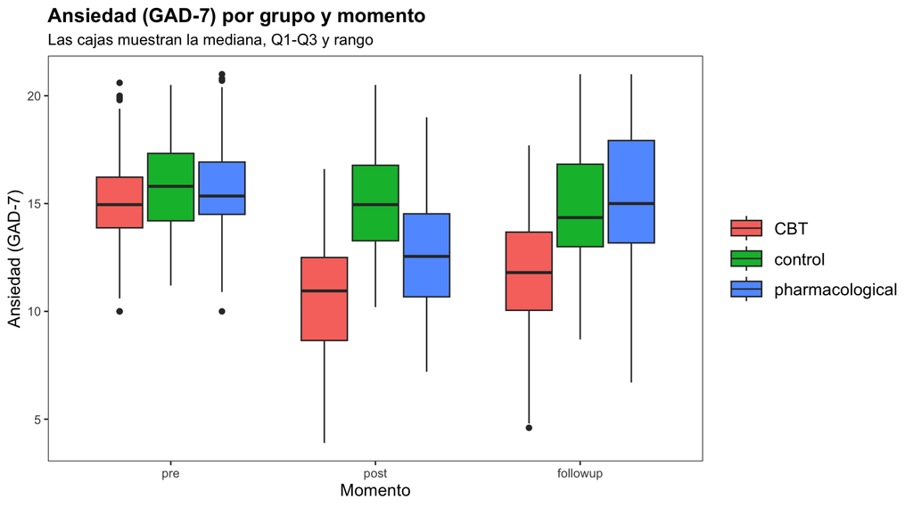

```r
# crear y asignar a un objeto descriptivo
fig_boxplot_anxiety <- ggplot(
  data    = data_long,
  mapping = aes(x = timepoint, y = anxiety, fill = group)
) +
  geom_boxplot() +
  labs(
    title    = "Ansiedad (GAD-7) por grupo y momento",
    subtitle = "Las cajas muestran la mediana, Q1-Q3 y rango",
    x        = "Momento",
    y        = "Ansiedad (GAD-7)",
    fill     = "Grupo"
  ) +
  theme_apa()

# mostrar en el documento
fig_boxplot_anxiety
```

```r
# guardar a output/
ggsave(
  filename = "../exercises/output/fig_boxplot_anxiety.png",
  plot     = fig_boxplot_anxiety,
  width    = 9, height = 5, dpi = 300
)
```

## Gráfico de medias con error estándar (trayectorias)

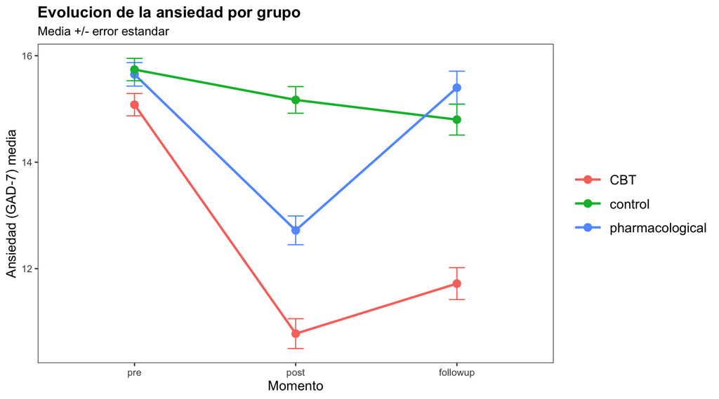

```r
# crear y asignar a un objeto descriptivo
fig_trayectorias_anxiety <- ggplot(
  data    = descriptivos,
  mapping = aes(x = timepoint, y = media,
                color = group, group = group)
) +
  geom_point(size = 3) +
  geom_line(linewidth = 1) +
  geom_errorbar(aes(ymin = media - se, ymax = media + se),
                width = 0.1) +
  labs(
    title    = "Evolucion de la ansiedad por grupo",
    subtitle = "Media +/- error estandar",
    x        = "Momento",
    y        = "Ansiedad (GAD-7) media",
    color    = "Grupo"
  ) +
  theme_apa()

# mostrar en el documento
fig_trayectorias_anxiety
```

```r
# guardar a output/
ggsave(
  filename = "../exercises/output/fig_trayectorias_anxiety.png",
  plot     = fig_trayectorias_anxiety,
  width    = 9, height = 5, dpi = 300
)
```

**ImportantLectura visual**

Si las **líneas son paralelas** → el cambio en el tiempo es igual en los tres grupos → no hay interacción. Si las **líneas no son paralelas** → el cambio en el tiempo *depende* del grupo → hay interacción.

Aquí las líneas claramente NO son paralelas: CBT baja mucho y se mantiene, farmacológico baja y rebota, control apenas cambia. Esperamos una interacción significativa.

# Paso 5 · Model

## Ajustar el ANOVA mixto

```r
modelo_mixto <- aov_ez(
  id      = "patient_id",   # identificador del sujeto
  dv      = "anxiety",      # variable dependiente
  data    = data_long,      # formato largo
  within  = "timepoint",    # factor intra-sujeto (3 niveles)
  between = "group"         # factor entre-sujetos (3 niveles)
)
```

### Output crudo de `afex::aov_ez()`

```r
modelo_mixto
```

```
Anova Table (Type 3 tests)

Response: anxiety
           Effect           df   MSE          F  ges p.value
1           group       2, 297 17.44  34.40 *** .163   <.001
2       timepoint 1.69, 501.82  2.00 303.98 *** .142   <.001
3 group:timepoint 3.38, 501.82  2.00  85.13 *** .085   <.001
---
Signif. codes:  0 '***' 0.001 '**' 0.01 '*' 0.05 '+' 0.1 ' ' 1

Sphericity correction method: GG
```

### Tabla formateada con `nice()` + `kable()`

**Tip¿Qué hace cada función?**

- **`afex::nice()`** — toma el objeto `afex_aov` y devuelve un **data frame limpio** con las columnas formateadas como las verías en un paper: F con asteriscos de significación, p-valores como “<.001”, grados de libertad con corrección GG, etc. Es el “traductor” del output crudo a formato APA.
- **`knitr::kable()`** — toma cualquier data frame y lo renderiza como **tabla HTML** (con `format = "html"`) bonita en el documento Quarto. No cambia el contenido, solo cambia la presentación visual.

Encadenadas con `|>`: primero formateamos el ANOVA → luego lo presentamos como tabla. Cada función hace una cosa, en su sitio.

**WarningLlamamos `afex::nice()` con el prefijo del paquete**

`nice` es un nombre genérico que también existe en el paquete `car` (cargado indirectamente por otros paquetes). Si llamas a `nice(modelo_mixto)` sin el prefijo, R puede usar la versión equivocada y devolver:

```
Error in UseMethod("nice", object) :
  no applicable method for 'nice' applied to an object of class "c('aov', 'lm')"
```

**Solución:** usa siempre **`afex::nice(...)`** (con `afex::` delante) — así no hay ambigüedad.

```r
afex::nice(modelo_mixto) |>
  kable(
    format    = "html",
    caption   = "ANOVA mixto: ansiedad ~ timepoint x group",
    col.names = c("Efecto", "df", "MSE", "F", "ges (eta^2 generalizado)", "p"),
    escape    = FALSE
  )
```

ANOVA mixto: ansiedad ~ timepoint x group

| Efecto | df | MSE | F | ges (eta^2 generalizado) | p |
| --- | --- | --- | --- | --- | --- |
| group | 2, 297 | 17.44 | 34.40 *** | .163 | <.001 |
| timepoint | 1.69, 501.82 | 2.00 | 303.98 *** | .142 | <.001 |
| group:timepoint | 3.38, 501.82 | 2.00 | 85.13 *** | .085 | <.001 |

**Tip¿Qué es cada columna?**

- **df** — grados de libertad. Para `timepoint` aparecen como decimales (`1.69, 501.82`) porque `afex` aplicó la **corrección de Greenhouse-Geisser** automáticamente al detectar violación de esfericidad.
- **MSE** — *mean squared error* (varianza residual del término de error correspondiente).
- **F** — estadístico F. Los asteriscos indican significación: `*` p < .05, `**` p < .01, `***` p < .001.
- **ges (η²G)** — *generalized eta squared* (Olejnik & Algina, 2003). Tamaño del efecto recomendado para diseños mixtos. Más comparable entre estudios que el η² parcial cuando los diseños difieren.
- **p** — p-valor.

**Interpretación de η²G (Cohen, 1988):** 0.01 = pequeño · 0.06 = mediano · 0.14 = grande.

## Intervalos de confianza para el tamaño del efecto

La tabla de `nice()` ya da el η² generalizado, pero **sin intervalos de confianza**. Para añadirlos usamos `effectsize::eta_squared()` con la misma métrica:

```r
eta_squared(model = modelo_mixto, generalized = TRUE) |>
  kable(
    format  = "html",
    caption = "Eta cuadrado generalizado con intervalos de confianza al 95%",
    digits  = 3
  )
```

Eta cuadrado generalizado con intervalos de confianza al 95%

| Parameter | Eta2_generalized | CI | CI_low | CI_high |
| --- | --- | --- | --- | --- |
| group | 0.163 | 0.95 | 0.101 | 1 |
| timepoint | 0.142 | 0.95 | 0.101 | 1 |
| group:timepoint | 0.085 | 0.95 | 0.049 | 1 |

**Note¿Por qué dos llamadas distintas para lo mismo?**

`afex::nice()` te da el ges como número puntual (suficiente para una tabla resumen). `effectsize::eta_squared(generalized = TRUE)` calcula la **misma métrica** pero añade el IC al 95% — útil para reportes APA. Si solo quieres el número, ahórrate el segundo paso.

## Post-hoc: ¿entre qué grupos y momentos están las diferencias?

### Efectos simples del tiempo dentro de cada grupo

```r
emm_within <- emmeans(object = modelo_mixto, specs = ~ timepoint | group)

# convertir a data frame para que kable() lo formatee bien
pairs(x = emm_within, adjust = "holm") |>
  as.data.frame() |>
  kable(
    format  = "html",
    caption = "Comparaciones por pares: timepoint dentro de cada grupo (Holm)",
    digits  = 3
  )
```

Comparaciones por pares: timepoint dentro de cada grupo (Holm)

| contrast | group | estimate | SE | df | t.ratio | p.value |
| --- | --- | --- | --- | --- | --- | --- |
| pre - post | CBT | 4.303 | 0.161 | 297 | 26.803 | 0.000 |
| pre - followup | CBT | 3.361 | 0.219 | 297 | 15.318 | 0.000 |
| post - followup | CBT | -0.942 | 0.165 | 297 | -5.708 | 0.000 |
| pre - post | control | 0.564 | 0.161 | 297 | 3.513 | 0.001 |
| pre - followup | control | 0.940 | 0.219 | 297 | 4.284 | 0.000 |
| post - followup | control | 0.376 | 0.165 | 297 | 2.278 | 0.023 |
| pre - post | pharmacological | 2.939 | 0.161 | 297 | 18.307 | 0.000 |
| pre - followup | pharmacological | 0.251 | 0.219 | 297 | 1.144 | 0.254 |
| post - followup | pharmacological | -2.688 | 0.165 | 297 | -16.288 | 0.000 |

### Diferencias entre grupos en cada momento

```r
emm_between <- emmeans(object = modelo_mixto, specs = ~ group | timepoint)

pairs(x = emm_between, adjust = "holm") |>
  as.data.frame() |>
  kable(
    format  = "html",
    caption = "Comparaciones por pares: grupos dentro de cada timepoint (Holm)",
    digits  = 3
  )
```

Comparaciones por pares: grupos dentro de cada timepoint (Holm)

| contrast | timepoint | estimate | SE | df | t.ratio | p.value |
| --- | --- | --- | --- | --- | --- | --- |
| CBT - control | pre | -0.654 | 0.305 | 297 | -2.143 | 0.099 |
| CBT - pharmacological | pre | -0.572 | 0.305 | 297 | -1.874 | 0.124 |
| control - pharmacological | pre | 0.082 | 0.305 | 297 | 0.269 | 0.788 |
| CBT - control | post | -4.393 | 0.381 | 297 | -11.539 | 0.000 |
| CBT - pharmacological | post | -1.936 | 0.381 | 297 | -5.085 | 0.000 |
| control - pharmacological | post | 2.457 | 0.381 | 297 | 6.454 | 0.000 |
| CBT - control | followup | -3.075 | 0.422 | 297 | -7.284 | 0.000 |
| CBT - pharmacological | followup | -3.682 | 0.422 | 297 | -8.722 | 0.000 |
| control - pharmacological | followup | -0.607 | 0.422 | 297 | -1.438 | 0.152 |

## Gráfico de interacción del modelo (con IC 95%)

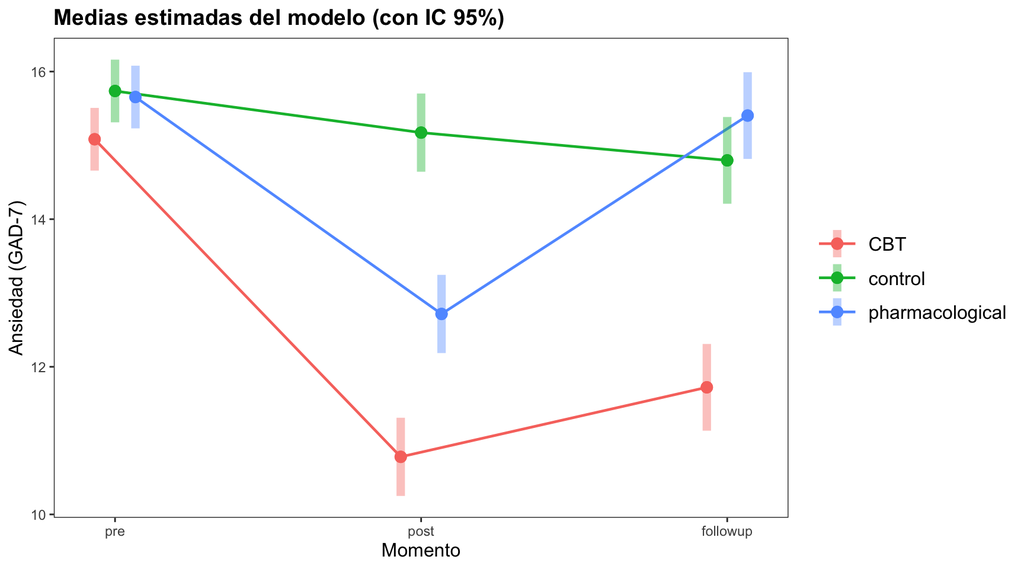

```r
# crear y asignar a un objeto descriptivo
fig_interaccion_anxiety <- emmip(
  object  = modelo_mixto,
  formula = group ~ timepoint,
  CIs     = TRUE
) +
  labs(
    title = "Medias estimadas del modelo (con IC 95%)",
    x     = "Momento",
    y     = "Ansiedad (GAD-7)"
  ) +
  theme_apa()

# mostrar en el documento
fig_interaccion_anxiety
```

```r
# guardar a output/
ggsave(
  filename = "../exercises/output/fig_interaccion_anxiety.png",
  plot     = fig_interaccion_anxiety,
  width    = 9, height = 5, dpi = 300
)
```

# Paso 6 · Report

## Resumen narrativo de los resultados

**Pregunta de investigación:** ¿la evolución de la ansiedad a lo largo del tratamiento (pre → post → followup) difiere entre los tres grupos (CBT, farmacológico, control)?

### Efectos principales y la interacción

El ANOVA mixto reveló los tres efectos esperados como significativos:

- **Efecto del tiempo** (factor within): la ansiedad cambió a lo largo del seguimiento, considerando todos los grupos juntos.
- **Efecto del grupo** (factor between): los tres grupos difirieron en su nivel medio de ansiedad.
- **Interacción `timepoint × group`**: **el cambio temporal NO fue igual en los tres grupos** — esta es la pregunta clave del ensayo.

La interacción es lo importante. Sin ella, podríamos concluir solo que “los grupos difieren” o “la ansiedad cambió en el tiempo” — pero sin un efecto diferencial del tratamiento, el ensayo no aportaría evidencia clínica.

### Conclusión clínica

CBT y tratamiento farmacológico son ambos eficaces a corto plazo, pero **CBT muestra mejor mantenimiento** del efecto a 3 meses post-tratamiento. Estos resultados son consistentes con la literatura sobre psicoterapia vs. farmacoterapia para trastornos de ansiedad: los efectos de la psicoterapia suelen persistir más allá del fin del tratamiento, mientras que los farmacológicos pueden revertir tras la retirada.

**WarningDos cosas que NO podemos concluir**

1. **Causalidad sobre el mecanismo**: el ANOVA nos dice *qué* grupos difieren, pero no *por qué* (mecanismo psicológico vs. neurobiológico).
2. **Generalización**: estos son datos sintéticos. En un estudio real habría que comprobar la representatividad de la muestra, los criterios de inclusión, los abandonos, etc.

# Exportar los gráficos

Para incluir los gráficos en un manuscrito, póster o presentación necesitamos guardarlos como archivos. Hay dos casos según el tipo de gráfico.

## Gráficos de `ggplot2` → `ggsave()`

A lo largo del documento ya hemos guardado las figuras junto a su creación. El patrón general:

```r
# 1. Asignar el grafico a un objeto con nombre descriptivo
mi_grafico <- ggplot(...) + ...

# 2. Mostrarlo en el documento
mi_grafico

# 3. Guardarlo con ggsave
ggsave(
  filename = "../exercises/output/mi_grafico.png",
  plot     = mi_grafico,
  width    = 9,            # pulgadas (default unit)
  height   = 5,
  dpi      = 300           # 300 DPI = calidad publicacion
)
```

`ggsave()` por defecto guarda **el último gráfico mostrado** si omites `plot`, pero es mejor pasarle el objeto explícitamente — así sabes exactamente qué se está guardando.

**Las tres figuras del análisis ya están en `exercises/output/`:**

- `fig_boxplot_anxiety.png`
- `fig_trayectorias_anxiety.png`
- `fig_interaccion_anxiety.png`

## ¿Qué formato elegir?

| Formato | Cuándo usarlo |
| --- | --- |
| **PNG** (`.png`) | Por defecto. Buena calidad, soporta transparencia. Para web, slides, manuscritos en Word. Especifica `dpi = 300` para imprimir. |
| **TIFF** (`.tiff`) | El formato estándar exigido por **muchos journals científicos** (Nature, Lancet, Elsevier…). Sin pérdida, alta calidad. Especifica `dpi = 300` o más, y usa `compression = "lzw"` para reducir tamaño. |
| **PDF** (`.pdf`) | Vectorial: se escala sin pixelarse. Ideal para LaTeX, posters grandes. No soporta transparencia bien. |
| **SVG** (`.svg`) | Vectorial editable: se puede modificar después en Illustrator/Inkscape. Útil para retocar etiquetas o colores manualmente. |
| **EPS** (`.eps`) | Vectorial. Lo piden algunos journals tradicionales. |
| **JPEG** (`.jpg`) | **Evitar** para gráficos científicos: la compresión introduce artefactos en líneas finas y texto. |